```r
library(igraph)
library(data.table)
library(readr)
library(tidyr)
library(igraph)
library(dplyr)
library(matrixcalc)
library(rlist)
library(sets)
df <- read.csv("C:/Users/10331/OneDrive/Desktop/social_and_task_network.csv")
```

```r
social <- df[,-4]
task <- df[-3 ]
social
```

```
##     ego alter social_tie
## 1     1     1      0.000
## 2     1     2      0.000
## 3     1     3      0.000
## 4     1     4      0.000
## 5     1     5      5.625
## 6     1     6      1.500
## 7     1     7      0.000
## 8     1     8      0.000
## 9     1     9      0.000
## 10    1    10      0.000
## 11    1    11      0.000
## 12    1    12      0.000
## 13    1    13      0.000
## 14    1    14      0.000
```

[output cut: 470 more lines]

```r
#question1
#(a:social)
print("Social")
```

```
## [1] "Social"
```

```r
social <- social[social$social_tie != 0,]
row.names(social)=NULL
gs <- graph.data.frame(social,directed = TRUE)
gs
```

```
## IGRAPH 338dcf3 DN-- 19 57 --
## + attr: name (v/c), social_tie (e/n)
## + edges from 338dcf3 (vertex names):
##  [1] 1 ->5  1 ->6  1 ->22 2 ->22 4 ->8  5 ->1  5 ->6  5 ->22 6 ->1  6 ->5
## [11] 6 ->9  7 ->10 8 ->4  9 ->6  10->7  10->12 11->15 12->10 12->16 12->18
## [21] 15->11 16->12 16->17 16->18 16->19 16->22 17->16 17->18 17->19 17->21
## [31] 18->12 18->16 18->17 18->19 18->20 18->21 19->16 19->17 19->18 19->20
## [41] 19->21 19->22 20->18 20->19 20->21 21->17 21->18 21->20 21->22 22->1
## [51] 22->2  22->5  22->11 22->16 22->18 22->19 22->21
```

```r
print("Social")
```

```
## [1] "Social"
```

```r
dins <- degree(gs,v = V(gs),mode = "in")
douts <- degree(gs,mode = "out")
print("in")
```

```
## [1] "in"
```

```r
dins
```

```
##  1  2  4  5  6  7  8  9 10 11 12 15 16 17 18 19 20 21 22
##  3  1  1  3  3  1  1  1  2  2  3  1  5  4  7  5  3  5  6
```

```r
print("out")
```

```
## [1] "out"
```

```r
douts
```

```
##  1  2  4  5  6  7  8  9 10 11 12 15 16 17 18 19 20 21 22
##  3  1  1  3  3  1  1  1  2  1  3  1  5  4  6  6  3  4  8
```

```r
closes <- closeness(gs,mode = "all")
print("Social")
```

```
## [1] "Social"
```

```r
closes
```

```
##           1           2           4           5           6           7
## 0.013157895 0.012345679 0.003086420 0.013157895 0.011363636 0.009433962
##           8           9          10          11          12          15
## 0.003086420 0.009708738 0.010989011 0.012658228 0.012820513 0.010638298
##          16          17          18          19          20          21
## 0.014285714 0.012500000 0.014705882 0.014084507 0.012345679 0.013888889
##          22
## 0.015151515
```

```r
print("Social")
```

```
## [1] "Social"
```

```r
betws <- betweenness(gs)
betws
```

```
##           1           2           4           5           6           7
##  24.0000000   0.0000000   0.0000000  24.0000000  28.0000000   0.0000000
##           8           9          10          11          12          15
##   0.0000000   0.0000000  28.0000000  15.0000000  52.0000000   0.0000000
##          16          17          18          19          20          21
##  45.8333333   0.8333333  33.0000000  14.7500000   0.2500000  13.5000000
##          22
## 126.8333333
```

```r
print("Social")
```

```
## [1] "Social"
```

```r
prs <- page.rank(gs)
prs$vector
```

```
##          1          2          4          5          6          7          8
## 0.04276027 0.01615060 0.05263158 0.04276027 0.05115620 0.02693356 0.05263158
##          9         10         11         12         15         16         17
## 0.02238899 0.04479722 0.08238245 0.04944339 0.07791982 0.06184064 0.05174036
##         18         19         20         21         22
## 0.08468420 0.06133638 0.04122745 0.05951279 0.07770226
```

```r
#(b:social)
print("Social")
```

```
## [1] "Social"
```

```r
print("cor:indegree-outdegree")
```

```
## [1] "cor:indegree-outdegree"
```

```r
cor(dins,douts)
```

```
## [1] 0.948282
```

```r
print("cor:indegree-closeness")
```

```
## [1] "cor:indegree-closeness"
```

```r
cor(dins,closes)
```

```
## [1] 0.7079371
```

```r
print("cor:indegree-betweenness")
```

```
## [1] "cor:indegree-betweenness"
```

```r
cor(dins,betws)
```

```
## [1] 0.5991529
```

```r
print("cor:indegree-page.rank")
```

```
## [1] "cor:indegree-page.rank"
```

```r
cor(dins,prs$vector)
```

```
## [1] 0.5568503
```

```r
print("cor:outdegree-closeness")
```

```
## [1] "cor:outdegree-closeness"
```

```r
cor(douts,closes)
```

```
## [1] 0.6660651
```

```r
print("cor:outdegree-betweenness")
```

```
## [1] "cor:outdegree-betweenness"
```

```r
cor(douts,betws)
```

```
## [1] 0.7242923
```

```r
print("cor:outdegree-page.rank")
```

```
## [1] "cor:outdegree-page.rank"
```

```r
cor(douts,prs$vector)
```

```
## [1] 0.4907911
```

```r
print("cor:closeness-betweenness")
```

```
## [1] "cor:closeness-betweenness"
```

```r
cor(closes,betws)
```

```
## [1] 0.4852587
```

```r
print("cor:closeness-page.rank")
```

```
## [1] "cor:closeness-page.rank"
```

```r
cor(closes,prs$vector)
```

```
## [1] 0.2602387
```

```r
print("cor:betweenness-page.rank")
```

```
## [1] "cor:betweenness-page.rank"
```

```r
cor(betws,prs$vector)
```

```
## [1] 0.4189853
```

From the above, we can see that the most closely correlated measures are indegree and outdegree. Which means for most nodes, the social relationships are reciprocated.

```r
#(a:task)
print("Task")
```

```
## [1] "Task"
```

```r
task <- task[task$task_tie != 0,]
row.names(task)=NULL
gt <- graph.data.frame(task,directed = TRUE)
gt
```

```
## IGRAPH 33be062 DN-- 20 48 --
## + attr: name (v/c), task_tie (e/n)
## + edges from 33be062 (vertex names):
##  [1] 1 ->22 2 ->22 4 ->8  5 ->22 6 ->22 7 ->22 8 ->4  9 ->22 10->22 11->22
## [11] 13->18 13->22 14->22 15->22 16->19 16->22 17->18 17->21 17->22 18->13
## [21] 18->17 18->21 18->22 19->16 19->20 19->22 20->19 20->22 21->17 21->18
## [31] 21->22 22->1  22->2  22->5  22->6  22->7  22->9  22->10 22->11 22->13
## [41] 22->14 22->15 22->16 22->17 22->18 22->19 22->20 22->21
```

```r
print("Task")
```

```
## [1] "Task"
```

```r
dint <- degree(gt,v = V(gt),mode = "in")
doutt <- degree(gt,mode = "out")
print("in")
```

```
## [1] "in"
```

```r
dint
```

```
##  1  2  4  5  6  7  8  9 10 11 13 14 15 16 17 18 19 20 21 22
##  1  1  1  1  1  1  1  1  1  1  2  1  1  2  3  4  3  2  3 17
```

```r
print("out")
```

```
## [1] "out"
```

```r
doutt
```

```
##  1  2  4  5  6  7  8  9 10 11 13 14 15 16 17 18 19 20 21 22
##  1  1  1  1  1  1  1  1  1  1  2  1  1  2  3  4  3  2  3 17
```

```r
closet <- closeness(gt,mode = "all")
print("Task")
```

```
## [1] "Task"
```

```r
closet
```

```
##           1           2           4           5           6           7
## 0.013698630 0.013698630 0.002770083 0.013698630 0.013698630 0.013698630
##           8           9          10          11          13          14
## 0.002770083 0.013698630 0.013698630 0.013698630 0.013888889 0.013698630
##          15          16          17          18          19          20
## 0.013698630 0.013888889 0.014084507 0.014285714 0.014084507 0.013888889
##          21          22
## 0.014084507 0.017543860
```

```r
print("Task")
```

```
## [1] "Task"
```

```r
betwt <- betweenness(gt)
betwt
```

```
##   1   2   4   5   6   7   8   9  10  11  13  14  15  16  17  18  19  20  21  22
##   0   0   0   0   0   0   0   0   0   0   0   0   0   0   0   2   1   0   0 257
```

```r
print("Task")
```

```
## [1] "Task"
```

```r
prt <- page.rank(gt)
prt$vector
```

```
##          1          2          4          5          6          7          8
## 0.02333208 0.02333208 0.05000000 0.02333208 0.02333208 0.02333208 0.05000000
##          9         10         11         13         14         15         16
## 0.02333208 0.02333208 0.02333208 0.03814414 0.02333208 0.02333208 0.03944171
##         17         18         19         20         21         22
## 0.05322438 0.06970382 0.05685753 0.03944171 0.05322438 0.31664155
```

```r
#(b:Task)
print("Task")
```

```
## [1] "Task"
```

```r
print("cor:indegree-outdegree")
```

```
## [1] "cor:indegree-outdegree"
```

```r
cor(dint,doutt)
```

```
## [1] 1
```

```r
print("cor:indegree-closeness")
```

```
## [1] "cor:indegree-closeness"
```

```r
cor(dint,closet)
```

```
## [1] 0.3649698
```

```r
print("cor:indegree-betweenness")
```

```
## [1] "cor:indegree-betweenness"
```

```r
cor(dint,betwt)
```

```
## [1] 0.9668378
```

```r
print("cor:indegree-page.rank")
```

```
## [1] "cor:indegree-page.rank"
```

```r
cor(dint,prt$vector)
```

```
## [1] 0.9900638
```

```r
print("cor:outdegree-closeness")
```

```
## [1] "cor:outdegree-closeness"
```

```r
cor(doutt,closet)
```

```
## [1] 0.3649698
```

```r
print("cor:outdegree-betweenness")
```

```
## [1] "cor:outdegree-betweenness"
```

```r
cor(doutt,betwt)
```

```
## [1] 0.9668378
```

```r
print("cor:outdegree-page.rank")
```

```
## [1] "cor:outdegree-page.rank"
```

```r
cor(doutt,prt$vector)
```

```
## [1] 0.9900638
```

```r
print("cor:closeness-betweenness")
```

```
## [1] "cor:closeness-betweenness"
```

```r
cor(closet,betwt)
```

```
## [1] 0.3063969
```

```r
print("cor:closeness-page.rank")
```

```
## [1] "cor:closeness-page.rank"
```

```r
cor(closet,prt$vector)
```

```
## [1] 0.23672
```

```r
print("cor:betweenness-page.rank")
```

```
## [1] "cor:betweenness-page.rank"
```

```r
cor(betwt,prt$vector)
```

```
## [1] 0.9743543
```

From the above, we can see that indegree and outdegree are perfectly correlated. Which means for all nodes, the task relationships are reciprocated.

```r
#Correlation Comparision of two table
print("Social and Task")
```

```
## [1] "Social and Task"
```

```r
print("cor:indegree")
```

```
## [1] "cor:indegree"
```

```r
#cor(dins,dint)
print("0.5578869")
```

```
## [1] "0.5578869"
```

```r
print("cor:outdegree")
```

```
## [1] "cor:outdegree"
```

```r
#cor(douts,doutt)
print("0.6996636")
```

```
## [1] "0.6996636"
```

```r
print("cor:closeness")
```

```
## [1] "cor:closeness"
```

```r
#cor(closes,closet)
print("0.4132661")
```

```
## [1] "0.4132661"
```

```r
print("cor:betweennesspage.rank")
```

```
## [1] "cor:betweennesspage.rank"
```

```r
#cor(betws,betwt)
print("0.7516857")
```

```
## [1] "0.7516857"
```

```r
print("cor:page.rank")
```

```
## [1] "cor:page.rank"
```

```r
#cor(prs$vector,prt$vector)
print("0.1730575")
```

```
## [1] "0.1730575"
```

```r
#THose code works on my local machine, but when i create HTML with KNIT, it fails so I print out the output manually.
```

The highest correlation existing between two betweenness scores, Which makes sense too. The people that are information bridge could be bridge in both social and task relationships. And these people performs as coordinator or gateholder.

```r
#Question2
#(a)
social$type <- "Social"
colnames(social)[3] = "Tie"
means = mean(social$Tie)
for (i in 1:nrow(social)){
  if (social[i,"Tie"]>means){
    social[i,"Strength"] = "Strong"
  } else{
    social[i,"Strength"] = "Weak"
  }
}
task$type <- "Task"
colnames(task)[3] = "Tie"
meant = mean(task$Tie)
for (i in 1:nrow(task)){
  if (task[i,"Tie"]>meant){
    task[i,"Strength"] = "Strong"
  } else{
    task[i,"Strength"] = "Weak"
  }
}
comb <- rbind(social,task)
row.names(comb)=NULL
g <- graph.data.frame(comb)
comb
```

```
##     ego alter    Tie   type Strength
## 1     1     5  5.625 Social   Strong
## 2     1     6  1.500 Social     Weak
## 3     1    22  1.875 Social   Strong
## 4     2    22  0.375 Social     Weak
## 5     4     8  1.875 Social   Strong
## 6     5     1  5.250 Social   Strong
## 7     5     6  1.500 Social     Weak
## 8     5    22  0.750 Social     Weak
## 9     6     1  1.125 Social     Weak
## 10    6     5  1.500 Social     Weak
## 11    6     9  0.375 Social     Weak
## 12    7    10  1.875 Social   Strong
## 13    8     4  1.875 Social   Strong
## 14    9     6  0.375 Social     Weak
```

[output cut: 91 more lines]

```r
gc <- graph.data.frame(comb,directed = TRUE)
gc
```

```
## IGRAPH 340213c DN-- 21 105 --
## + attr: name (v/c), Tie (e/n), type (e/c), Strength (e/c)
## + edges from 340213c (vertex names):
##  [1] 1 ->5  1 ->6  1 ->22 2 ->22 4 ->8  5 ->1  5 ->6  5 ->22 6 ->1  6 ->5
## [11] 6 ->9  7 ->10 8 ->4  9 ->6  10->7  10->12 11->15 12->10 12->16 12->18
## [21] 15->11 16->12 16->17 16->18 16->19 16->22 17->16 17->18 17->19 17->21
## [31] 18->12 18->16 18->17 18->19 18->20 18->21 19->16 19->17 19->18 19->20
## [41] 19->21 19->22 20->18 20->19 20->21 21->17 21->18 21->20 21->22 22->1
## [51] 22->2  22->5  22->11 22->16 22->18 22->19 22->21 1 ->22 2 ->22 4 ->8
## [61] 5 ->22 6 ->22 7 ->22 8 ->4  9 ->22 10->22 11->22 13->18 13->22 14->22
## [71] 15->22 16->19 16->22 17->18 17->21 17->22 18->13 18->17 18->21 18->22
## + ... omitted several edges
```

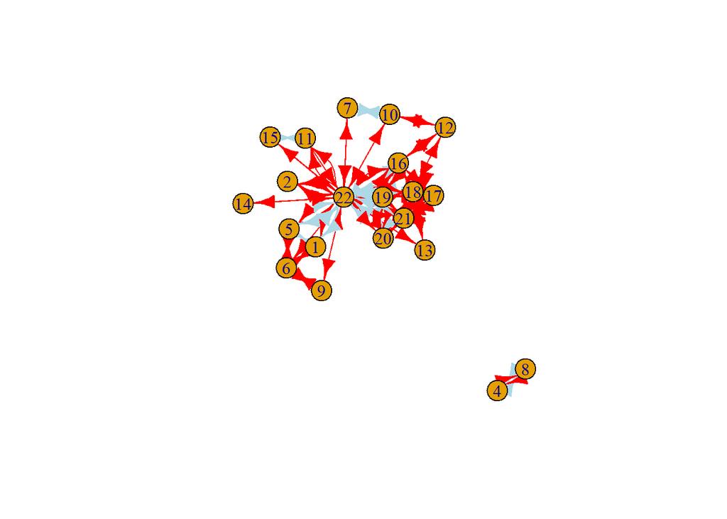

```r
plot(gc, edge.color = c("light blue","red")[as.factor(E(gc)$Strength)])
```

```r
ties <-matrix(ncol = 2)
strong = comb[comb$Strength=='Strong',]
unique_ego = unique(strong$ego)
unique_alter = unique(strong$alter)
strong_list = unique(do.call(c, list(unique_ego, unique_alter)))
```

```r
for (i in 1:length(strong_list)){
  tmp = strong[strong$ego==strong_list[i], ]
  if (length(unique(tmp$alter))>1){
    tmp1 <-combn(unique(tmp$alter),m=2)
    for (j in 1:ncol(tmp1) ){
      v1=tmp1[1,j]
      v2 = tmp1[2,j]
      ties <-rbind(c(v1,v2), ties)
      ties <-rbind(c(v2,v1), ties)
    }
  }
}
```

```r
nodes = unique(df$ego)
ties=na.omit(ties)
ties= ties[!duplicated(ties),]
final <- graph.data.frame(ties, vertices = nodes, directed = TRUE)

E(difference(final,g, byname = TRUE))
```

```
## + 11/11 edges from 343547e (vertex names):
##  [1] 1 ->21 1 ->19 5 ->21 5 ->19 16->20 19->5  19->1  20->16 21->19 21->5
## [11] 21->1
```

There are 15 nodes involved holds strong ties and could form Triadic Closure. However, there’s 11 violations of Strong Triadic Closure, under the definition of mean.

```r
#(b)
social1 = social[,]
medians = median(social1$Tie)
for (i in 1:nrow(social1)){
  if (social1[i,"Tie"]>medians){
    social1[i,"Strength"] = "Strong"
  } else{
    social1[i,"Strength"] = "Weak"
  }
}
task1 <- task[,]
mediant = median(task1$Tie)
for (i in 1:nrow(task1)){
  if (task1[i,"Tie"]>mediant){
    task1[i,"Strength"] = "Strong"
  } else{
    task1[i,"Strength"] = "Weak"
  }
}
comb2 <- rbind(social1,task1)
row.names(comb2)=NULL
comb2
```

```
##     ego alter    Tie   type Strength
## 1     1     5  5.625 Social   Strong
## 2     1     6  1.500 Social   Strong
## 3     1    22  1.875 Social   Strong
## 4     2    22  0.375 Social     Weak
## 5     4     8  1.875 Social   Strong
## 6     5     1  5.250 Social   Strong
## 7     5     6  1.500 Social   Strong
## 8     5    22  0.750 Social     Weak
## 9     6     1  1.125 Social     Weak
## 10    6     5  1.500 Social   Strong
## 11    6     9  0.375 Social     Weak
## 12    7    10  1.875 Social   Strong
## 13    8     4  1.875 Social   Strong
## 14    9     6  0.375 Social     Weak
```

[output cut: 91 more lines]

```r
ties <-matrix(ncol = 2)
strong = comb2[comb2$Strength=='Strong',]
unique_ego = unique(strong$ego)
unique_alter = unique(strong$alter)
strong_list = unique(do.call(c, list(unique_ego, unique_alter)))
```

```r
for (i in 1:length(strong_list)){
  tmp = strong[strong$ego==strong_list[i], ]
  if (length(unique(tmp$alter))>1){
    tmp1 <-combn(unique(tmp$alter),m=2)
    for (j in 1:ncol(tmp1) ){
      v1=tmp1[1,j]
      v2 = tmp1[2,j]
      ties <-rbind(c(v1,v2), ties)
      ties <-rbind(c(v2,v1), ties)
    }
  }
}
```

```r
ties=na.omit(ties)
ties= ties[!duplicated(ties),]
final <- graph.data.frame(ties, vertices = nodes, directed = TRUE)

E(difference(final,g, byname = TRUE))
```

```
## + 75/75 edges from 34548ef (vertex names):
##  [1] 1 ->13 1 ->21 1 ->19 1 ->18 1 ->16 1 ->15 1 ->7  5 ->13 5 ->21 5 ->19
## [11] 5 ->18 5 ->16 5 ->15 5 ->7  6 ->13 6 ->21 6 ->19 6 ->18 6 ->16 6 ->15
## [21] 6 ->7  7 ->13 7 ->21 7 ->19 7 ->18 7 ->16 7 ->15 7 ->6  7 ->5  7 ->1
## [31] 15->13 15->21 15->19 15->18 15->16 15->7  15->6  15->5  15->1  16->13
## [41] 16->21 16->20 16->15 16->7  16->6  16->5  16->1  18->15 18->7  18->6
## [51] 18->5  18->1  19->13 19->15 19->7  19->6  19->5  19->1  20->16 21->13
## [61] 21->19 21->16 21->15 21->7  21->6  21->5  21->1  13->21 13->19 13->16
## [71] 13->15 13->7  13->6  13->5  13->1
```

There are 75 violations of Strong Triadic Closure, under the defination of median.

```r
comb1 <- comb[,-c(3,4)]
comb1 <- rbind(comb1[,c("ego", "alter","Strength")],comb1[,c("alter", "ego","Strength")])
comb1[comb1$Strength == "Strong","Strength"] = 1
comb1[comb1$Strength == "Weak","Strength"] = 0
comb1$Strength <- as.numeric(comb1$Strength)
comb1 <- aggregate(comb1[,3],comb1[,-3],sum)
colnames(comb1)[3] = "Strength"
for (i in nrow(comb1)){
  for (j in nrow(comb1)){
    if ((comb1[i,"ego"] == comb1[j,"alter"]) & (comb1[j,"ego"] == comb1[i,"alter"])){
      if (comb1[i,"Strength"] == "Strong"){
        comb1[i,"Strength"] = "Strong"
        comb1[j,"Strength"] = "Strong"
      }else if(comb1[j,"Strength"] == "Strong"){
        comb1[i,"Strength"] = "Strong"
        comb1[j,"Strength"] = "Strong"
      }
    }
  }
}
comb1[comb1$Strength == 2,"Strength"] = "Strong"
comb1[comb1$Strength == 1,"Strength"] = "Strong"
comb1[comb1$Strength == 0,"Strength"] = "Weak"
comb1
```

```
##    ego alter Strength
## 1    5     1   Strong
## 2    6     1     Weak
## 3   22     1   Strong
## 4   22     2     Weak
## 5    8     4   Strong
## 6    1     5   Strong
## 7    6     5     Weak
## 8   22     5   Strong
## 9    1     6     Weak
## 10   5     6     Weak
## 11   9     6     Weak
## 12  22     6     Weak
## 13  10     7   Strong
## 14  22     7     Weak
```

[output cut: 65 more lines]

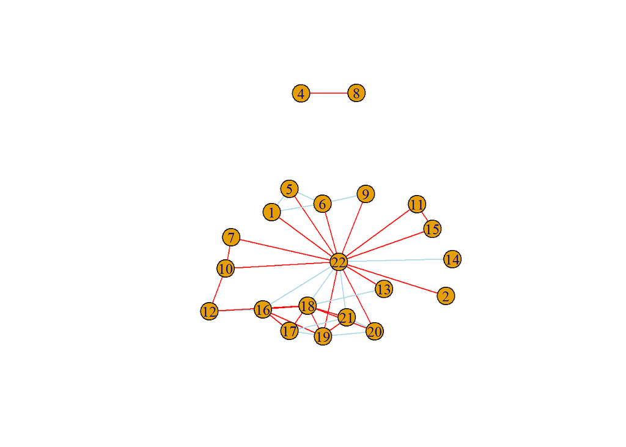

```r
gc1 <- graph.data.frame(comb1,directed = FALSE)
gc1 <- simplify(gc1,remove.multiple = TRUE,remove.loops = TRUE)
plot(gc1, edge.color = c("light blue","red")[as.factor(E(gc)$Strength)])
```

```r
gc1
```

```
## IGRAPH 346a610 UN-- 21 40 --
## + attr: name (v/c)
## + edges from 346a610 (vertex names):
##  [1] 5 --6  5 --22 5 --1  6 --22 6 --1  6 --9  22--1  22--9  22--10 22--7
## [11] 22--15 22--16 22--18 22--11 22--17 22--19 22--21 22--13 22--20 22--2
## [21] 22--14 8 --4  10--7  10--12 12--16 12--18 15--11 16--18 16--17 16--19
## [31] 18--17 18--19 18--21 18--13 18--20 17--19 17--21 19--21 19--20 21--20
```

```r
#Question3
#(a)

#Difinition1: Mean

gs <- graph.data.frame(social,directed = TRUE)
gt <- graph.data.frame(task,directed = TRUE)

betws <- betweenness(gs)
ebetws <- edge_betweenness(gs, e = E(gs), directed = TRUE)
print("Social node:")
```

```
## [1] "Social node:"
```

```r
betws
```

```
##           1           2           4           5           6           7
##  24.0000000   0.0000000   0.0000000  24.0000000  28.0000000   0.0000000
##           8           9          10          11          12          15
##   0.0000000   0.0000000  28.0000000  15.0000000  52.0000000   0.0000000
##          16          17          18          19          20          21
##  45.8333333   0.8333333  33.0000000  14.7500000   0.2500000  13.5000000
##          22
## 126.8333333
```

```r
print("Social edge:")
```

```
## [1] "Social edge:"
```

```r
ebetws
```

```
##  [1]  1.000000 13.000000 26.000000 16.000000  1.000000  1.000000 13.000000
##  [8] 26.000000 15.000000 15.000000 14.000000 16.000000  1.000000 16.000000
## [15] 14.000000 30.000000 16.000000 26.000000 30.000000 12.000000  1.000000
## [22] 15.000000  4.250000  1.750000  3.250000 37.583333  5.500000  2.833333
## [29]  4.250000  4.250000 21.000000  4.500000  4.333333  5.416667  6.833333
## [36]  6.916667  3.000000  2.833333  2.500000  3.833333  1.250000 17.333333
## [43]  4.833333  6.083333  5.333333  3.416667  4.583333  3.583333 17.916667
## [50] 22.000000 14.000000 22.000000 30.000000 16.833333 18.500000  9.750000
## [57]  9.750000
```

```r
betwt <- betweenness(gt)
print("Task node:")
```

```
## [1] "Task node:"
```

```r
betwt
```

```
##   1   2   4   5   6   7   8   9  10  11  13  14  15  16  17  18  19  20  21  22
##   0   0   0   0   0   0   0   0   0   0   0   0   0   0   0   2   1   0   0 257
```

```r
ebetwt <- edge_betweenness(gt, e = E(gt), directed = TRUE)
print("Task edge:")
```

```
## [1] "Task edge:"
```

```r
ebetwt
```

```
##  [1] 17.0 17.0  1.0 17.0 17.0 17.0  1.0 17.0 17.0 17.0  2.0 15.0 17.0 17.0  1.5
## [16] 15.5  1.5  1.0 14.5  2.0  1.5  1.5 14.0  1.5  1.5 15.0  1.5 15.5  1.0  1.5
## [31] 14.5 17.0 17.0 17.0 17.0 17.0 17.0 17.0 17.0 15.0 17.0 17.0 15.5 14.5 14.0
## [46] 15.0 15.5 14.5
```

```r
#(b)

#Difinition2: Mean

datas <- data.frame(E(gs)$Strength,ebetws)
datas <- datas[order(-ebetws),]
datas
```

```
##    E.gs..Strength    ebetws
## 26           Weak 37.583333
## 16           Weak 30.000000
## 19           Weak 30.000000
## 53           Weak 30.000000
## 3          Strong 26.000000
## 8            Weak 26.000000
## 18           Weak 26.000000
## 50           Weak 22.000000
## 52           Weak 22.000000
## 31           Weak 21.000000
## 55           Weak 18.500000
## 49           Weak 17.916667
## 42           Weak 17.333333
## 54           Weak 16.833333
```

[output cut: 43 more lines]

```r
datat <- data.frame(E(gt)$Strength,ebetwt)
datat <- datat[order(-ebetwt),]
datat
```

```
##    E.gt..Strength ebetwt
## 1          Strong   17.0
## 2            Weak   17.0
## 4          Strong   17.0
## 5          Strong   17.0
## 6            Weak   17.0
## 8            Weak   17.0
## 9            Weak   17.0
## 10           Weak   17.0
## 13           Weak   17.0
## 14           Weak   17.0
## 32         Strong   17.0
## 33           Weak   17.0
## 34         Strong   17.0
## 35           Weak   17.0
```

[output cut: 34 more lines]

```r
#(a)

#Definition2: Median

gs <- graph.data.frame(social1,directed = TRUE)
gt <- graph.data.frame(task1,directed = TRUE)

betws <- betweenness(gs)
ebetws <- edge_betweenness(gs, e = E(gs), directed = TRUE)
print("Social node:")
```

```
## [1] "Social node:"
```

```r
betws
```

```
##           1           2           4           5           6           7
##  24.0000000   0.0000000   0.0000000  24.0000000  28.0000000   0.0000000
##           8           9          10          11          12          15
##   0.0000000   0.0000000  28.0000000  15.0000000  52.0000000   0.0000000
##          16          17          18          19          20          21
##  45.8333333   0.8333333  33.0000000  14.7500000   0.2500000  13.5000000
##          22
## 126.8333333
```

```r
print("Social edge:")
```

```
## [1] "Social edge:"
```

```r
ebetws
```

```
##  [1]  1.000000 13.000000 26.000000 16.000000  1.000000  1.000000 13.000000
##  [8] 26.000000 15.000000 15.000000 14.000000 16.000000  1.000000 16.000000
## [15] 14.000000 30.000000 16.000000 26.000000 30.000000 12.000000  1.000000
## [22] 15.000000  4.250000  1.750000  3.250000 37.583333  5.500000  2.833333
## [29]  4.250000  4.250000 21.000000  4.500000  4.333333  5.416667  6.833333
## [36]  6.916667  3.000000  2.833333  2.500000  3.833333  1.250000 17.333333
## [43]  4.833333  6.083333  5.333333  3.416667  4.583333  3.583333 17.916667
## [50] 22.000000 14.000000 22.000000 30.000000 16.833333 18.500000  9.750000
## [57]  9.750000
```

```r
betwt <- betweenness(gt)
print("Task node:")
```

```
## [1] "Task node:"
```

```r
betwt
```

```
##   1   2   4   5   6   7   8   9  10  11  13  14  15  16  17  18  19  20  21  22
##   0   0   0   0   0   0   0   0   0   0   0   0   0   0   0   2   1   0   0 257
```

```r
ebetwt <- edge_betweenness(gt, e = E(gt), directed = TRUE)
print("Task edge:")
```

```
## [1] "Task edge:"
```

```r
ebetwt
```

```
##  [1] 17.0 17.0  1.0 17.0 17.0 17.0  1.0 17.0 17.0 17.0  2.0 15.0 17.0 17.0  1.5
## [16] 15.5  1.5  1.0 14.5  2.0  1.5  1.5 14.0  1.5  1.5 15.0  1.5 15.5  1.0  1.5
## [31] 14.5 17.0 17.0 17.0 17.0 17.0 17.0 17.0 17.0 15.0 17.0 17.0 15.5 14.5 14.0
## [46] 15.0 15.5 14.5
```

```r
#(b)

#Difinition2: Median

datas <- data.frame(E(gs)$Strength,ebetws)
datas <- datas[order(-ebetws),]
datas
```

```
##    E.gs..Strength    ebetws
## 26           Weak 37.583333
## 16           Weak 30.000000
## 19           Weak 30.000000
## 53           Weak 30.000000
## 3          Strong 26.000000
## 8            Weak 26.000000
## 18           Weak 26.000000
## 50           Weak 22.000000
## 52           Weak 22.000000
## 31           Weak 21.000000
## 55           Weak 18.500000
## 49         Strong 17.916667
## 42           Weak 17.333333
## 54           Weak 16.833333
```

[output cut: 43 more lines]

```r
datat <- data.frame(E(gt)$Strength,ebetwt)
datat <- datat[order(-ebetwt),]
datat
```

```
##    E.gt..Strength ebetwt
## 1          Strong   17.0
## 2          Strong   17.0
## 4          Strong   17.0
## 5          Strong   17.0
## 6            Weak   17.0
## 8          Strong   17.0
## 9            Weak   17.0
## 10         Strong   17.0
## 13           Weak   17.0
## 14         Strong   17.0
## 32         Strong   17.0
## 33           Weak   17.0
## 34         Strong   17.0
## 35         Strong   17.0
```

[output cut: 34 more lines]

As shown in the data table above, for both definition: The high social betweenness tend to be weaker, and high social betweenness tend to be stronger. And high task betweenness tend to be stronger, low task betweenness tend to be weaker. It makes sense, because task edges have high betweenness process more information going back and forth between two people. And taks edges with low betweenness tend to be less commnicated so they are weaker. While, high betweenness among social edges, those people might be to distracted by so many friends, so the link is weaker. And low betweenness among social edges, meaning those are their friend of a only few, so they commnicate more frequently, so those are stronger.

```r
#Question4

gs <- graph.data.frame(social,directed = TRUE)
gt <- graph.data.frame(task,directed = TRUE)

gsm <- as_adjacency_matrix(gs)
gtm <- as_adjacency_matrix(gt)
```

```r
distance <- distances(gs)
distance
```

```
##      1   2   4   5   6   7   8   9  10  11  12  15  16  17  18  19  20  21  22
## 1    0   2 Inf   1   1   5 Inf   2   4   2   3   3   2   3   2   2   3   2   1
## 2    2   0 Inf   2   3   5 Inf   4   4   2   3   3   2   3   2   2   3   2   1
## 4  Inf Inf   0 Inf Inf Inf   1 Inf Inf Inf Inf Inf Inf Inf Inf Inf Inf Inf Inf
## 5    1   2 Inf   0   1   5 Inf   2   4   2   3   3   2   3   2   2   3   2   1
## 6    1   3 Inf   1   0   6 Inf   1   5   3   4   4   3   4   3   3   4   3   2
## 7    5   5 Inf   5   6   0 Inf   7   1   5   2   6   3   4   3   4   4   4   4
## 8  Inf Inf   1 Inf Inf Inf   0 Inf Inf Inf Inf Inf Inf Inf Inf Inf Inf Inf Inf
## 9    2   4 Inf   2   1   7 Inf   0   6   4   5   5   4   5   4   4   5   4   3
## 10   4   4 Inf   4   5   1 Inf   6   0   4   1   5   2   3   2   3   3   3   3
## 11   2   2 Inf   2   3   5 Inf   4   4   0   3   1   2   3   2   2   3   2   1
## 12   3   3 Inf   3   4   2 Inf   5   1   3   0   4   1   2   1   2   2   2   2
## 15   3   3 Inf   3   4   6 Inf   5   5   1   4   0   3   4   3   3   4   3   2
## 16   2   2 Inf   2   3   3 Inf   4   2   2   1   3   0   1   1   1   2   2   1
## 17   3   3 Inf   3   4   4 Inf   5   3   3   2   4   1   0   1   1   2   1   2
## 18   2   2 Inf   2   3   3 Inf   4   2   2   1   3   1   1   0   1   1   1   1
## 19   2   2 Inf   2   3   4 Inf   4   3   2   2   3   1   1   1   0   1   1   1
## 20   3   3 Inf   3   4   4 Inf   5   3   3   2   4   2   2   1   1   0   1   2
## 21   2   2 Inf   2   3   4 Inf   4   3   2   2   3   2   1   1   1   1   0   1
## 22   1   1 Inf   1   2   4 Inf   3   3   1   2   2   1   2   1   1   2   1   0
```

```r
print("No relationship/Walk at all for Social:")
```

```
## [1] "No relationship/Walk at all for Social:"
```

```r
sum(distance > 100 )/2
```

```
## [1] 34
```

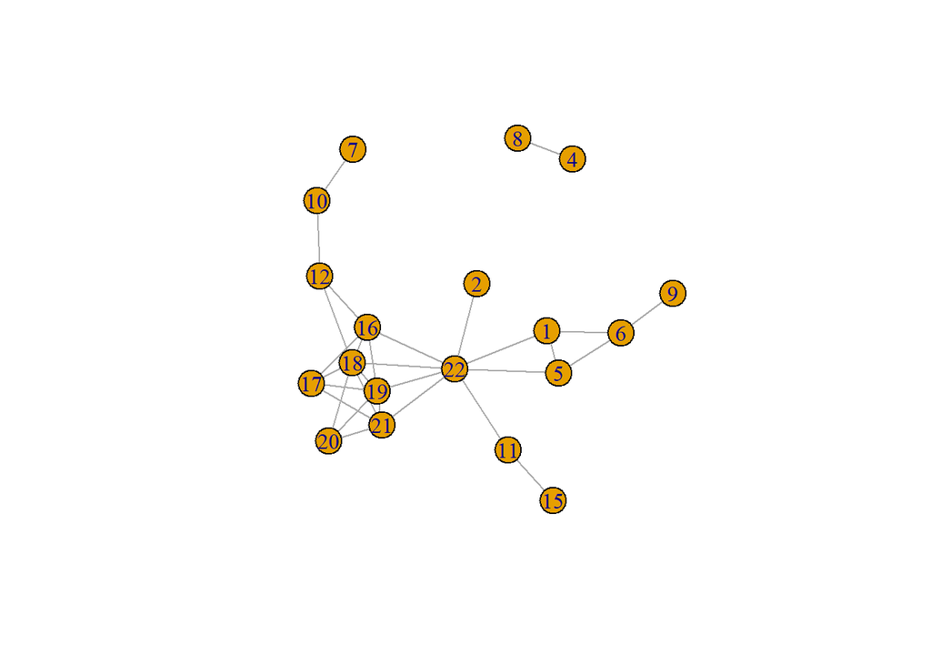

```r
gsm <- graph.adjacency(gsm,mode = "undirected")
gsm <- simplify(gsm,remove.multiple = TRUE,remove.loops = TRUE)
plot(gsm)
```

And yes we can see from the graph after removing all the multiples, and prove our calculation above. Since there’s only two standing alone, the number of no walk is combination of those two and everything else.

```r
distance <- distances(gt)
distance
```

```
##      1   2   4   5   6   7   8   9  10  11  13  14  15  16  17  18  19  20  21
## 1    0   2 Inf   2   2   2 Inf   2   2   2   2   2   2   2   2   2   2   2   2
## 2    2   0 Inf   2   2   2 Inf   2   2   2   2   2   2   2   2   2   2   2   2
## 4  Inf Inf   0 Inf Inf Inf   1 Inf Inf Inf Inf Inf Inf Inf Inf Inf Inf Inf Inf
## 5    2   2 Inf   0   2   2 Inf   2   2   2   2   2   2   2   2   2   2   2   2
## 6    2   2 Inf   2   0   2 Inf   2   2   2   2   2   2   2   2   2   2   2   2
## 7    2   2 Inf   2   2   0 Inf   2   2   2   2   2   2   2   2   2   2   2   2
## 8  Inf Inf   1 Inf Inf Inf   0 Inf Inf Inf Inf Inf Inf Inf Inf Inf Inf Inf Inf
## 9    2   2 Inf   2   2   2 Inf   0   2   2   2   2   2   2   2   2   2   2   2
## 10   2   2 Inf   2   2   2 Inf   2   0   2   2   2   2   2   2   2   2   2   2
## 11   2   2 Inf   2   2   2 Inf   2   2   0   2   2   2   2   2   2   2   2   2
## 13   2   2 Inf   2   2   2 Inf   2   2   2   0   2   2   2   2   1   2   2   2
## 14   2   2 Inf   2   2   2 Inf   2   2   2   2   0   2   2   2   2   2   2   2
## 15   2   2 Inf   2   2   2 Inf   2   2   2   2   2   0   2   2   2   2   2   2
## 16   2   2 Inf   2   2   2 Inf   2   2   2   2   2   2   0   2   2   1   2   2
```

[output cut: 27 more lines]

```r
print("No relationship/Walk at all for Task:")
```

```
## [1] "No relationship/Walk at all for Task:"
```

```r
sum(distance > 100 )/2
```

```
## [1] 36
```

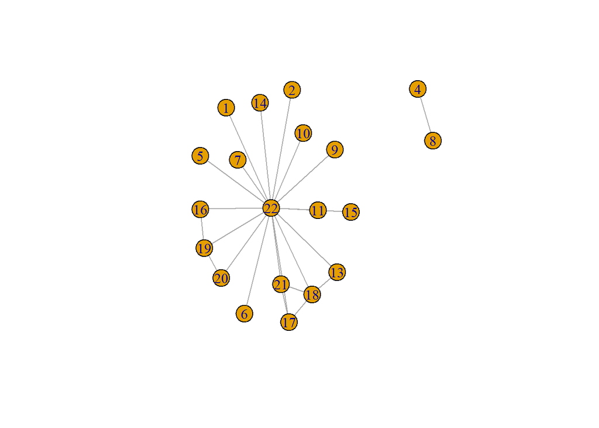

```r
gtm <- graph.adjacency(gtm,mode = "undirected")
gtm <- simplify(gtm,remove.multiple = TRUE,remove.loops = TRUE)
plot(gtm)
```

And yes we can see from the graph after removing all the multiples, and prove our calculation above. Since there’s only two standing alone, the number of no walk is combination of those two and everything else.

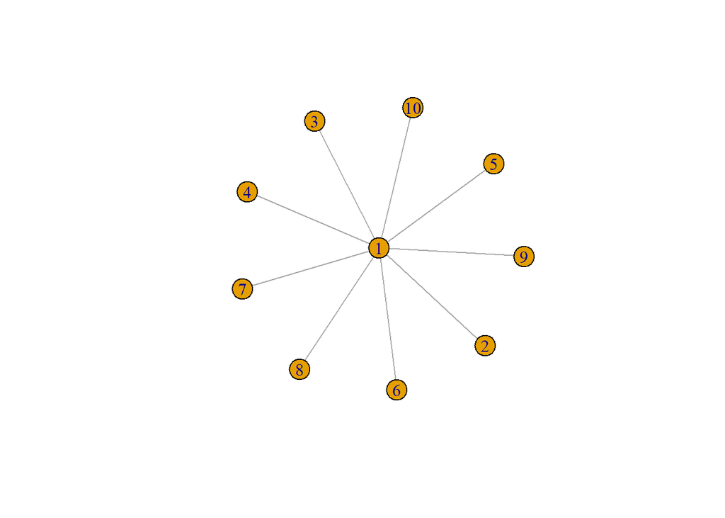

```r
#Question5
#network-level measure of degree centrality is equal to 1
#As network centrality is calculated by max minus all other degrees
#We could easily find that a star network of one level with any number of nodes would have network centrality = 1.

star1 = make_star(10, "undirected")
plot(star1)
```

```r
print("Star1 centrality")
```

```
## [1] "Star1 centrality"
```

```r
dc1 <- sum((max(degree(star1)) - degree(star1)))/((length(V(star1)) -1)*(length(V(star1))-2))
dc1
```

```
## [1] 1
```

```r
close <- closeness(star1,mode = "all")
max(close)
```

```
## [1] 0.1111111
```

```r
mean(close)
```

```
## [1] 0.06405229
```

```r
sd(close)
```

```
## [1] 0.01653479
```

```r
betw <- betweenness(star1)
mean(betw)
```

```
## [1] 3.6
```

```r
sd(betw)
```

```
## [1] 11.3842
```

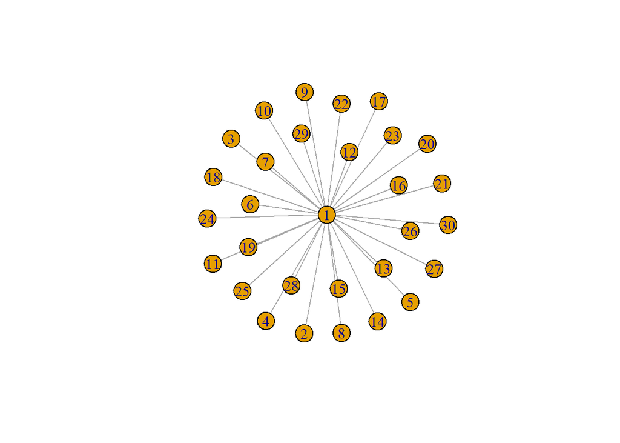

```r
star2 = make_star(30, "undirected")
plot(star2)
```

```r
print("Star2 centrality")
```

```
## [1] "Star2 centrality"
```

```r
dc2 <- sum((max(degree(star2)) - degree(star2)))/((length(V(star2)) -1)* (length(V(star2))-2))
dc2
```

```
## [1] 1
```

```r
close <- closeness(star2,mode = "all")
max(close)
```

```
## [1] 0.03448276
```

```r
mean(close)
```

```
## [1] 0.01810849
```

```r
sd(close)
```

```
## [1] 0.003092606
```

```r
betw <- betweenness(star2)
mean(betw)
```

```
## [1] 13.53333
```

```r
sd(betw)
```

```
## [1] 74.12512
```

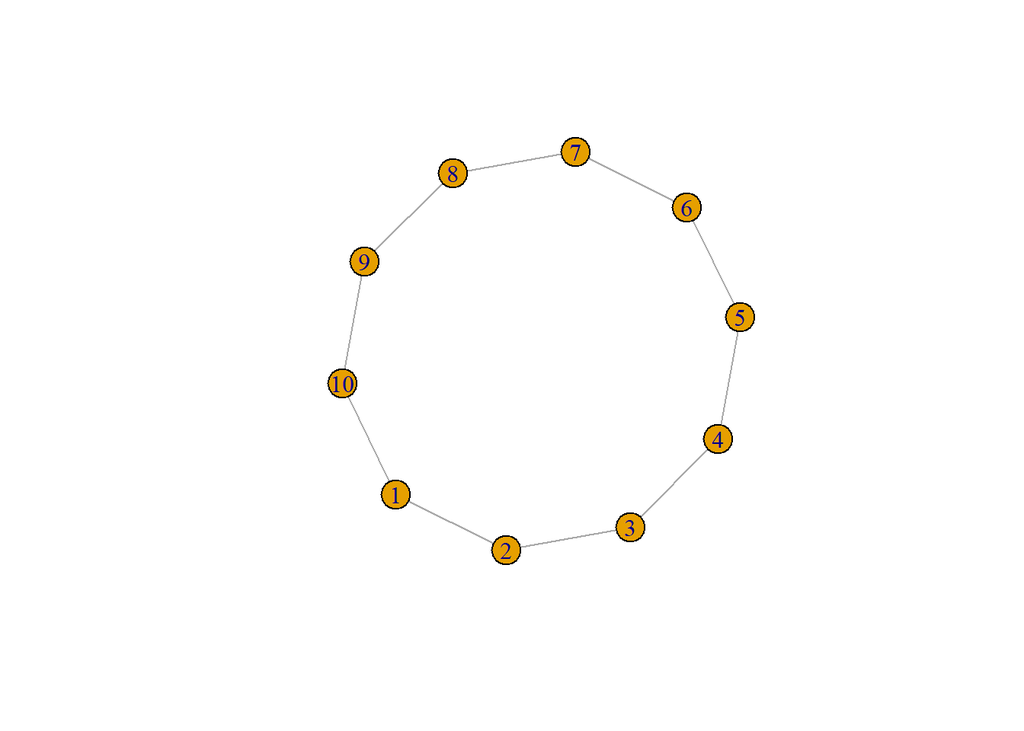

```r
#network-level measure of degree centrality is equal to 0
#As network centrality is calculated by max minus all other degrees
#We could easily find that a ring network with any number of nodes would have network centrality = 0.

ring1 = make_ring(10)
plot(ring1)
```

```r
print("ring1 centrality")
```

```
## [1] "ring1 centrality"
```

```r
dc1 <- sum((max(degree(ring1)) - degree(ring1)))/((length(V(ring1)) -1)* (length(V(ring1))-2))
dc1
```

```
## [1] 0
```

```r
close <- closeness(ring1,mode = "all")
max(close)
```

```
## [1] 0.04
```

```r
mean(close)
```

```
## [1] 0.04
```

```r
sd(close)
```

```
## [1] 0
```

```r
betw <- betweenness(ring1)
mean(betw)
```

```
## [1] 8
```

```r
sd(betw)
```

```
## [1] 0
```

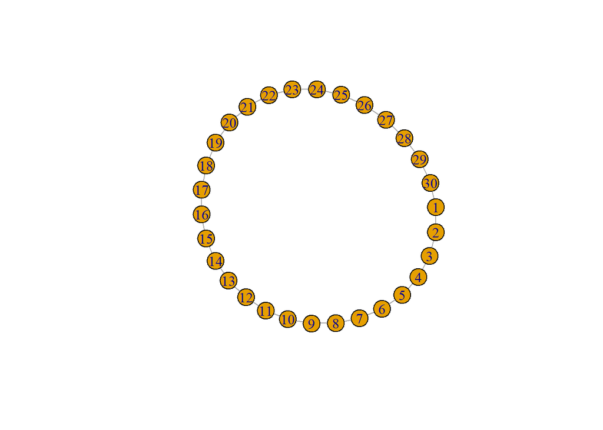

```r
ring2 = make_ring(30)
plot(ring2)
```

```r
print("ring2 centrality")
```

```
## [1] "ring2 centrality"
```

```r
dc2 <- sum((max(degree(ring2)) - degree(ring2)))/((length(V(ring2)) -1)* (length(V(ring2))-2))
dc2
```

```
## [1] 0
```

```r
close <- closeness(ring2,mode = "all")
max(close)
```

```
## [1] 0.004444444
```

```r
mean(close)
```

```
## [1] 0.004444444
```

```r
sd(close)
```

```
## [1] 0
```

```r
betw <- betweenness(ring2)
mean(betw)
```

```
## [1] 98
```

```r
sd(betw)
```

```
## [1] 0
```